# Preparation

```python
import numpy as np
import pandas as pd
```

```python
import matplotlib.pyplot as plt
data = pd.DataFrame({
'Gender': ['f', 'f', 'm', 'f', 'm',
'm', 'f', 'm', 'f', 'm', 'm'],
'TV': [3.4, 3.5, 2.6, 4.7, 4.1, 4.1,
5.1, 3.9, 3.7, 2.1, 4.3]
})
```

```python
grouped = data.groupby('Gender')
```

```
f         AxesSubplot(0.1,0.15;0.363636x0.75)
m    AxesSubplot(0.536364,0.15;0.363636x0.75)
dtype: object
```

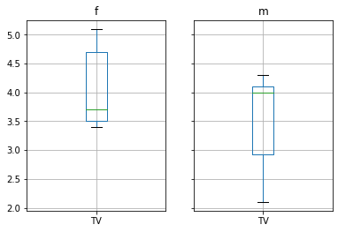

```python
grouped.boxplot()
```

```python
df_female = grouped.get_group('f')

value_female = grouped.get_group('f').values
print(df_female)
```

[output not shown]

```python
df2 = pd.read_csv('data/data2.txt', skipfooter=3, delimiter='[ ,]+') # skipfooter=n, n is the number of lines to ignore
                                             # [ ,]+ means one or more spaces and/or commas

df2
```

|  | ID | Weight | Value |
| --- | --- | --- | --- |
| 0 | 1 | 1.3 | 0.6 |
| 1 | 2 | 2.1 | 0.7 |
| 2 | 3 | 4.8 | 0.8 |
| 3 | 4 | 3.3 | 0.9 |

```python
# or using read_excel function:
data = pd.read_excel('data/Earlwood_Air_Data_17_18.xls', 'worksheet1', index_col=None, na_values=['NA'])
data.head()
```

|  | Date | Time | EARLWOOD WDR 1h average [°] | EARLWOOD TEMP 1h average [°C] | EARLWOOD WSP 1h average [m/s] | EARLWOOD NO 1h average [pphm] | EARLWOOD NO2 1h average [pphm] | EARLWOOD CO 1h average [ppm] | EARLWOOD OZONE 1h average [pphm] | EARLWOOD OZONE 4h rolling average [pphm] | EARLWOOD PM10 1h average [µg/m³] | EARLWOOD PM2.5 1h average [µg/m³] | EARLWOOD HUMID 1h average [%] | EARLWOOD SD1 1h average [°] | EARLWOOD CO 8h rolling average [ppm] |
| --- | --- | --- | --- | --- | --- | --- | --- | --- | --- | --- | --- | --- | --- | --- | --- |
| 0 | 01/01/2017 | 01:00 | 152.3 | 22.6 | 0.4 | 0.0 | 0.4 | NaN | 2.0 | 2.1 | 23.6 | 7.0 | 87.2 | 49.01 | NaN |
| 1 | 01/01/2017 | 02:00 | 134.0 | 22.6 | 0.3 | NaN | NaN | NaN | NaN | 2.2 | 21.0 | 6.6 | 87.2 | 46.56 | NaN |
| 2 | 01/01/2017 | 03:00 | 132.2 | 22.6 | 0.3 | 0.0 | 0.6 | NaN | 1.7 | 2.0 | 20.0 | 7.2 | 87.0 | 47.40 | NaN |
| 3 | 01/01/2017 | 04:00 | 125.8 | 22.7 | 0.2 | 0.0 | 0.5 | NaN | 1.7 | 1.8 | 21.4 | 7.1 | 87.2 | 53.70 | NaN |
| 4 | 01/01/2017 | 05:00 | 107.9 | 22.8 | 0.6 | 0.0 | 0.3 | NaN | 2.1 | 1.8 | 21.5 | 4.3 | 86.8 | 41.65 | NaN |

```python
from scipy.stats import cumfreq

x = np.random.randn(100)
```

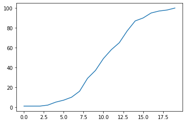

```python
plt.plot(cumfreq(x, 20)[0])
```

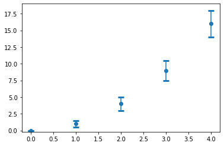

```python
 # Errorbars
x = np.arange(5)
y = x**2
errorBar = x/2
plt.errorbar(x,y, yerr=errorBar, fmt='o', capsize=5, capthick=3)
plt.xlim([-0.2, 4.2])
plt.ylim([-0.2, 19])
plt.show()
```

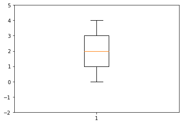

```python
# Boxplot
# 'Box' showing first quartile, median, and third quartile. Lines usually show 1.5*(quartiles difference)
# or maximal and minimal values
plt.boxplot(x, sym='*')  # with * we denote outliers - values outside the lines
plt.ylim([-2, 5])
plt.show()
```

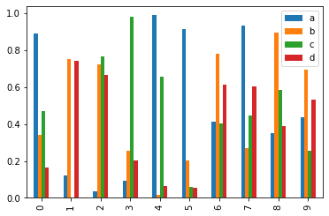

```python
# Barplot
import pandas as pd
df = pd.DataFrame(np.random.rand(10, 4), columns=['a', 'b', 'c', 'd'])
df.plot(kind='bar', grid=False)
plt.show()
```

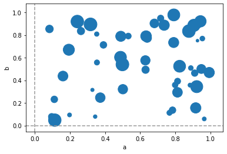

```python
# 2-D data
df2 = pd.DataFrame(np.random.rand(50, 3), columns=['a', 'b', 'c'])
df2.plot(kind='scatter', x='a', y='b', s=df2['c']*500) # parameter s is the size of marker (here dictated by column 'c')
plt.axhline(0, ls='--', color='#999999')
plt.axvline(0, ls='--', color='#999999')
plt.show()
```

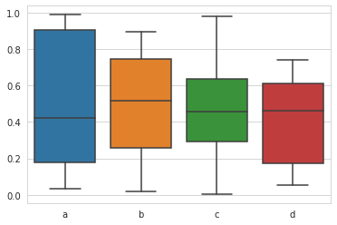

```python
import seaborn as sns


# Grouped Boxplots
sns.set_style('whitegrid')
sns.boxplot(data=df)
plt.show()
```

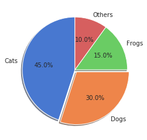

```python
# Pie plot
txtLabels = 'Cats', 'Dogs', 'Frogs', 'Others'
fractions = [45, 30, 15, 10]
offsets =(0, 0.05, 0, 0)

plt.pie(fractions, explode=offsets, labels=txtLabels,
            autopct='%1.1f%%', shadow=True, startangle=90,
            colors=sns.color_palette('muted') )
#plt.axis('equal')
plt.show()
```

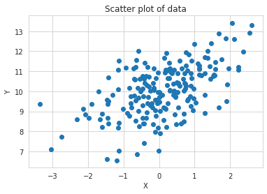

```python
# Line fitting

x = np.random.randn(200)
y = 10+0.5*x+np.random.randn(len(x))

# Scatter plot
plt.scatter(x,y)
plt.title('Scatter plot of data')
plt.xlabel('X')
plt.ylabel('Y')
plt.show()
```

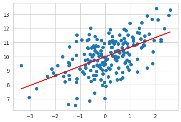

```python
M = np.vstack((np.ones(len(x)), x)).T
pars = np.linalg.lstsq(M,y)[0]
a = pars[0]
b = pars[1]
plt.scatter(x,y)
plt.plot(x, a + b*x, 'r')
plt.show()
```

Now we are going to simulate $k$ coin flippings $N$ times, and we will obtain **statistical probability** that we get head (or tail).

In the code, we use '1' to denote head, and '0' for tail.

```python
event = np.random.randint(2, size=12)
event
```

```
array([1, 1, 0, 1, 0, 1, 1, 1, 1, 1, 0, 0])
```

```python
np.random.choice(2, size=12)
```

[output not shown]

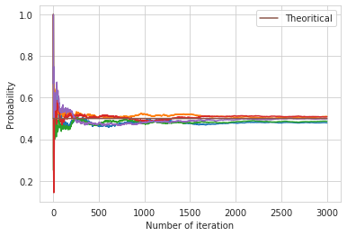

```python
N = 3000

for sim in range(0,5):
    event = np.random.randint(2, size=N)
    P_head = []
    N_head = 0
    for i in range(0, N):
        if(event[i] == 1):
            N_head += 1
        P_head.append(N_head/(i+1))

    plt.xlabel('Number of iteration')
    plt.ylabel('Probability')
    plt.plot(np.arange(1, N+1), P_head)

plt.plot(np.arange(1, N+1), [0.5]*N, label='Theoritical')
plt.legend()
```

## Rolling dice

Now we will calculate probabilities of two simple events that can happen when rolling dice. Let $A$ be the event that we got number $2$. Let $B$ be the event that we got even number. We will calculate theoretically their probabilities, and then we will verify the result by simulations.

**Event A:** There are six events with **equal** probabilites, from which we choose one (number $2$); hence $$P(A) = \frac{1}{6} = 0.1667$$

Now we simulate N dice throwings and plot **statistical probability** of event $A$.

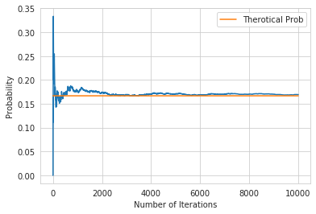

```python
N_max = 10000

P_A = []
N_A = 0

event = 1+np.random.randint(6, size=N_max)

for i in range(0, N_max):
    if(event[i] == 2):
        N_A += 1
    P_A.append(N_A/(i+1))

plt.xlabel('Number of Iterations')
plt.ylabel('Probability')
plt.plot(np.arange(1, N_max+1), P_A)

plt.plot(np.arange(1, N_max+1), [1/6]*N_max, label='Therotical Prob')
plt.legend()
```

**Event B:** Out of $6$ possible outcomes, 3 are even numbers, hence

$$P(B)=3/6=\frac{1}{2}=0.5$$

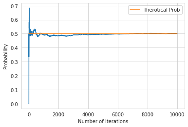

```python
N_max = 10000

P_A = []
N_A = 0

event = 1+np.random.randint(6, size=N_max)

for i in range(0, N_max):
    if(event[i] % 2 == 0):
        N_A += 1
    P_A.append(N_A/(i+1))

plt.xlabel('Number of Iterations')
plt.ylabel('Probability')
plt.plot(np.arange(1, N_max+1), P_A)

plt.plot(np.arange(1, N_max+1), [1/2]*N_max, label='Therotical Prob')
plt.legend()
```

## Events in Poker

Let us perform a few simple simulations to show the agreement between theoretical probability and empirical estimates as the number of samples grows.

Standard card deck consists of $52$ cards, each marked with one of four suits and one of $13$ ranks $1, 2, ..., 10, J, Q$, or $K$. Thus, there are $13$ cards per suit, and $4$ cards per rank.

Consider the experiment where a card is picked at random from the deck. Let $R$ be the event that the card is red and let $F$ denote the event that it is a face card. For each of the events $R$, $F$ and $R\cup F$, we determine the theoretical probability, and then approximate it via simulations.

**Event $R$**: There are $2$ red suites, each with $13$ cards, hence there are $26$ red cards, and $$P(R) = 26/52 = \frac{1}{2} = 0.5.$$

Following is a simulation of this event probability.

```python
from itertools import product, combinations
```

```python
# Definiion of cards
Rank = {1, 2, 3, 4, 5, 6, 7, 8, 9, 10, 'J', 'Q', 'K'}
Suits = {'S', 'C', 'H', 'D'}
Cards = list(product(Rank, Suits))  #Cartesian product
print(Cards)
```

```
[(1, 'H'), (1, 'S'), (1, 'D'), (1, 'C'), (2, 'H'), (2, 'S'), (2, 'D'), (2, 'C'), (3, 'H'), (3, 'S'), (3, 'D'), (3, 'C'), (4, 'H'), (4, 'S'), (4, 'D'), (4, 'C'), (5, 'H'), (5, 'S'), (5, 'D'), (5, 'C'), (6, 'H'), (6, 'S'), (6, 'D'), (6, 'C'), (7, 'H'), (7, 'S'), (7, 'D'), (7, 'C'), (8, 'H'), (8, 'S'),…
```

```python
Cards[0][1]
```

```
'H'
```

```
[0.4984, 0.505]
```

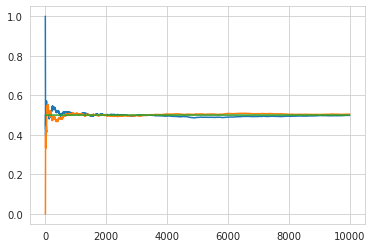

```python
P_Red_final = []
num_sim = 3

N = 10000

for sim in range(1, num_sim):
    P_red = []
    N_red = 0

    for i in range(0, N):
        index = np.random.randint(0, 52)
        if Cards[index][1] == 'H' or Cards[index][1] == 'D':
            N_red += 1
        P_red.append(N_red/(i+1))
    P_Red_final.append(N_red/N)

    plt.plot(np.arange(1, N+1), P_red)

plt.plot(np.arange(1, N+1), [0.5]*N)
print(P_Red_final)
```

**Face Card ($F$)**: There are $4$ suits, each with $3$ face cards, hence $4\times3=12$ face cards. Therefore, $$P(F) = 12/52 = \frac{3}{13} = 0.231.$$ Here is a simulation of this probability.

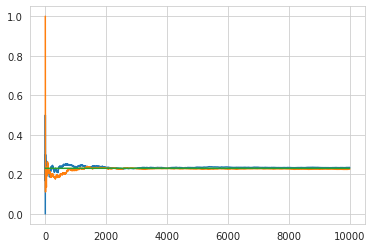

```python
P_Red_final = []
num_sim = 3

N = 10000

for sim in range(1, num_sim):
    P_red = []
    N_red = 0

    for i in range(0, N):
        index = np.random.randint(0, 52)
        if Cards[index][0] in {'J', 'K', 'Q'}:
            N_red += 1
        P_red.append(N_red/(i+1))
    P_Red_final.append(N_red/N)

    plt.plot(np.arange(1, N+1), P_red)

plt.plot(np.arange(1, N+1), [3/13]*N)
```

**Red or Face ($R\cup F$):** Let us first calculate the probability of the event $R\cap F$. There are two red suits, $♡$ and $♢$, and each has $3$ face cards, hence $|R\cap F|=6$. Therefore, $$P(R\cap F) = \frac6{52} = \frac{3}{26} = 0.115.$$ By inclusion-exclusion, $$P(R\cup F) = P(R) + P(F) - P(R\cap F) = 0.5 + 0. 231 - 0.115 = 0.615.$$

### Exercise: Simulate the intersection and union statistical probabilities.

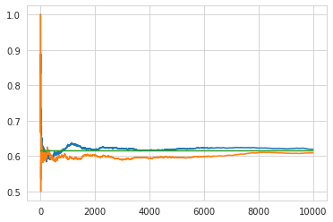

```python
P_Red_final = []
num_sim = 3

N = 10000

for sim in range(1, num_sim):
    P_red = []
    N_red = 0

    for i in range(0, N):
        index = np.random.randint(0, 52)
        if Cards[index][0] in {'J', 'K', 'Q'} or Cards[index][1] == 'H' or Cards[index][1] == 'D':
            N_red += 1
        P_red.append(N_red/(i+1))
    P_Red_final.append(N_red/N)

    plt.plot(np.arange(1, N+1), P_red)

plt.plot(np.arange(1, N+1), [0.615]*N)
```

# Permutaions and Combinations

## Permutations

We will find the number of variations without repetitions ($k$-permutations) of a set $A$, first, by finding all the possible variations, and then by directly calculating $\frac{|A|!}{(|A|-k)!}$.

We first treat the special case $k=|A|$ - permutations without repetitions (number of ways we can order the elements of a set).

```python
import itertools   # a library with combinatorial functions
A = {1, 2, 3}
permute_all = set(itertools.permutations(A))  # permutations() gives all the permutaions of a set
print("Permutations of set %s:  " %A)
for i in permute_all:
    print(i)
print;print("Number of permutations: ", len(permute_all))
```

```
Permutations of set {1, 2, 3}:
(3, 1, 2)
(1, 3, 2)
(3, 2, 1)
(2, 3, 1)
(1, 2, 3)
(2, 1, 3)
Number of permutations:  6
```

```python
# Direct calculation of |A|!:
from math import factorial
print(factorial(len(A)))
```

```
6
```

```python
A = {1, 2, 3, 4}
k = 3

# k-permutations of set A (variations without repetitions)
n = len(A)
permute_k = list(itertools.permutations(A, k))
print("%i-permutations (variations without repetitions) of set %s:  " %(k,A))
for i in permute_k:
    print(i)
print;print("Number of permutations = ", len(permute_k))
```

```
3-permutations (variations without repetitions) of set {1, 2, 3, 4}:
(1, 2, 3)
(1, 2, 4)
(1, 3, 2)
(1, 3, 4)
(1, 4, 2)
(1, 4, 3)
(2, 1, 3)
(2, 1, 4)
(2, 3, 1)
(2, 3, 4)
(2, 4, 1)
(2, 4, 3)
(3, 1, 2)
(3, 1, 4)
(3, 2, 1)
(3, 2, 4)
(3, 4, 1)
(3, 4, 2)
(4, 1, 2)
(4, 1, 3)
(4, 2, 1)
(4, 2, 3)
(4, 3, 1)
(4, 3, 2)
Number of permutations =  24
```

```python
# Direct calculation |A|!/(|A|-k)!
print(int(factorial(len(A))/factorial(len(A)-k)))
```

```
24
```

## Combinations

We will find the number of $k$-combinations of set $A$, first by finding all the combinations, and then by calculating ${|A|}\choose{k}$.

```python
# Direct calculation of |A|!/(k!(|A|-k)!)   (n choose k)
print(int(factorial(len(A))/(factorial(k)*factorial(len(A)-k))))
```

[output not shown]

```python
A = {'a', 'b', 'c', 'd'}
k = 2

kombinacije_k = list(itertools.combinations(A,k))
print("%i-combinations of set %s:\n" %(k,A))
for i in range(0, len(kombinacije_k)):
    print(''.join(kombinacije_k[i]) )
print;print("Number of combinations = %i!/(%i!(%i-%i)!) = " %(n,k,n,k), len(kombinacije_k))
```

```
2-combinations of set {'b', 'c', 'a', 'd'}:

bc
ba
bd
ca
cd
ad
Number of combinations = 4!/(2!(4-2)!) =  6
```

### QUESTION 3 IN THE BOOK ABOUT CARDS

```python
from itertools import product, permutations, combinations
from math import factorial
```

```python
# Definiion of cards
Rank = {1, 2, 3, 4, 5, 6, 7, 8, 9, 10, 'J', 'Q', 'K'}
Suits = {'S', 'C', 'H', 'D'}
Cards = list(product(Rank, Suits))  #Cartesian product
print(Cards)
```

```
[(1, 'H'), (1, 'S'), (1, 'D'), (1, 'C'), (2, 'H'), (2, 'S'), (2, 'D'), (2, 'C'), (3, 'H'), (3, 'S'), (3, 'D'), (3, 'C'), (4, 'H'), (4, 'S'), (4, 'D'), (4, 'C'), (5, 'H'), (5, 'S'), (5, 'D'), (5, 'C'), (6, 'H'), (6, 'S'), (6, 'D'), (6, 'C'), (7, 'H'), (7, 'S'), (7, 'D'), (7, 'C'), (8, 'H'), (8, 'S'),…
```

```
 Obtained statistical probabilities P(Face card) are [0.0026, 0.0029]
```

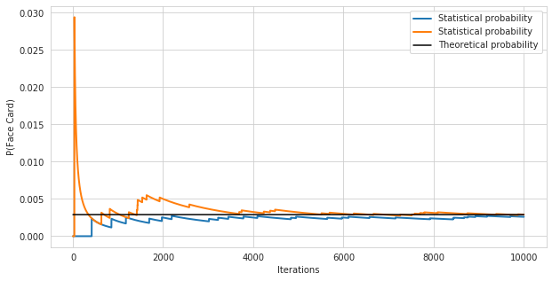

```python
P_F_final = []
for sim in range(1, num_sim):
    N_F = 0
    P_F = []
    for i in range(0, N):
        index = np.random.choice(52, 3, replace=False) # without repetition (without repeition)
        ranks = {Cards[index[0]][0], Cards[index[1]][0],Cards[index[2]][0]}
        if ranks == {'J', 'K', 'Q'}:
            N_F = N_F + 1
        P_F.append(N_F/(i+1))

    P_F_final.append(N_F/N)

    plt.plot(range(1, N+1), P_F, linewidth = 2.0, label = 'Statistical probability')
    plt.gcf().set_size_inches([10, 5])
    plt.xlabel('Iterations')
    plt.ylabel('P(Face Card)')

print("\n Obtained statistical probabilities P(Face card) are %s" %str(P_F_final))
plt.plot(range(1, N+1), [(4*4*4)/((52*51*50)/(3*2))]*N, 'k', label = 'Theoretical probability')
plt.legend()
plt.show()
```

## Conditional and unconditional probability

```python
import pandas as pd
import matplotlib.pyplot as plt

# read data:
data_por = pd.read_csv("data/student-por.csv")
data_por.head()  # pick into DataFrame
```

|  | school | sex | age | address | famsize | Pstatus | Medu | Fedu | Mjob | Fjob | ... | famrel | freetime | goout | Dalc | Walc | health | absences | G1 | G2 | G3 |
| --- | --- | --- | --- | --- | --- | --- | --- | --- | --- | --- | --- | --- | --- | --- | --- | --- | --- | --- | --- | --- | --- |
| 0 | GP | F | 18 | U | GT3 | A | 4 | 4 | at_home | teacher | ... | 4 | 3 | 4 | 1 | 1 | 3 | 4 | 0 | 11 | 11 |
| 1 | GP | F | 17 | U | GT3 | T | 1 | 1 | at_home | other | ... | 5 | 3 | 3 | 1 | 1 | 3 | 2 | 9 | 11 | 11 |
| 2 | GP | F | 15 | U | LE3 | T | 1 | 1 | at_home | other | ... | 4 | 3 | 2 | 2 | 3 | 3 | 6 | 12 | 13 | 12 |
| 3 | GP | F | 15 | U | GT3 | T | 4 | 2 | health | services | ... | 3 | 2 | 2 | 1 | 1 | 5 | 0 | 14 | 14 | 14 |
| 4 | GP | F | 16 | U | GT3 | T | 3 | 3 | other | other | ... | 4 | 3 | 2 | 1 | 2 | 5 | 0 | 11 | 13 | 13 |

5 rows × 33 columns

In the next example we use the following two attributes (columns of the DataFrame):

- `G3` - final grade related with the course subject (numeric: from 0 to 20, output target)
- `studytime` - weekly study time (numeric: 1 : < 2 hours, 2 : 2 to 5 hours, 3 : 5 to 10 hours, or 4 : > 10 hours)

```python
attributes = ['G3', 'studytime']
data_por = data_por[attributes]
data_por.head()
```

|  | G3 | studytime |
| --- | --- | --- |
| 0 | 11 | 2 |
| 1 | 11 | 2 |
| 2 | 12 | 2 |
| 3 | 14 | 3 |
| 4 | 13 | 2 |

The probability that a student's study-time falls in an interval can be approximated by

$${P(\text{study interval}) = \frac{\text{Number of students with this study interval}}{\text{Total number of students}}}$$

This is an emperical estimate. The larger the population (number of students involved) the precision of the estimate is better (provided that the samples are independent!).

```python
study_interval = data_por['studytime'].value_counts()
```

```python
total_student = data_por['studytime'].value_counts().sum()
```

```python
p_study_time = pd.DataFrame((study_interval/total_student).sort_index())
p_study_time.index =  ["< 2 hours","2 to 5 hours","5 to 10 hours","> 10 hours"]
p_study_time.columns = ['Probability']
```

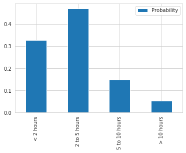

```python
p_study_time.plot.bar()
```

Let us call scores of at least 15 "high". We can construct two events "A student has high score" and "A student has low score". The probability of a student getting a high score can be approximated by

$$P(\text{high score}) = \frac{\text{Number of students with high scores}}{\text{Total number of students}}$$

```python
P_high = (data_por['G3'] >= 15).value_counts()
P_high
```

```
False    518
True     131
Name: G3, dtype: int64
```

```python
P_high.sum()
```

```
649
```

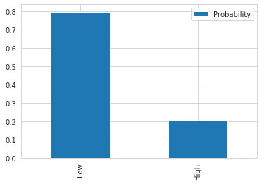

```python
P_high = pd.DataFrame(P_high/total_student)
P_high.index = ['Low', 'High']
P_high.columns = ['Probability']
P_high.plot.bar()
```

## Conditional Probability

Very often it is advantageous to infer the probability of certain events *conditioned on* other events. In this case, we want to find probability of a certain event, if we know (conditioned on) that some other event happen. For example, we want to estimate the probability that it will rain on a particular day, if we know (conditioned on) that certain type of cloud are present. These types of problems are called [statistical classification] (https://en.wikipedia.org/wiki/Statistical_classification), and concepts such as conditional probability and Bayes rule play an important role in its solution.

Hence, we proceed with more interesting observations.Suppose we want to find the probability of the various study-intervals given (conditioned on) that the student scored high. By conditional probability, this can be calculated by:

$$P(\text{study interval}\ |\ \text{highscore})=\frac{\text{Number of students with study interval AND highscore}}{\text{Total number of students with highscore}}$$

```python
data_temp = data_por['studytime'][data_por["G3"] >= 15]
```

```python
data_temp.head()
```

```
8     2
14    3
15    1
31    2
32    2
Name: studytime, dtype: int64
```

```python
data_temp2 = data_temp.value_counts().sort_index()
data_temp2
```

```
1    22
2    67
3    32
4    10
Name: studytime, dtype: int64
```

```python
data_temp1 = data_por["studytime"].value_counts().sort_index()
data_temp1
```

```
1    212
2    305
3     97
4     35
Name: studytime, dtype: int64
```

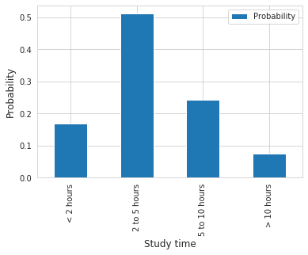

```python
P_T_given_high_score = pd.DataFrame(data_temp2/data_temp2.sum())
P_T_given_high_score.index = ["< 2 hours","2 to 5 hours","5 to 10 hours","> 10 hours"]
P_T_given_high_score.columns = ["Probability"]

P_T_given_high_score.plot.bar()
plt.xlabel("Study time",fontsize=12)
plt.ylabel("Probability",fontsize=12)
```

$$P(\text{student getting a highscore}\ |\ \text{study interval})=\frac{P(\text{study interval}\ |\ \text{the student scored high})P(\text{highscore})}{P(\text{study interval})}$$

```python
P_high_cond_T = P_T_given_high_score * P_high.loc["High"] / p_study_time
```

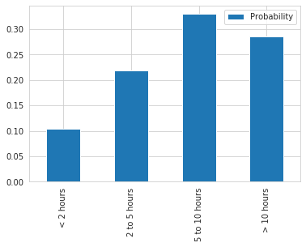

```python
P_high_cond_T.plot.bar()
```

### Excersie 2

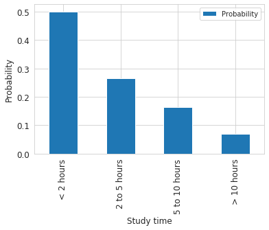

```python
data_math = pd.read_csv("data/student-mat.csv")
data_temp = data_math["studytime"].value_counts()
P_study_time_m = pd.DataFrame(data_temp/data_temp.sum())
P_study_time_m.index = ["< 2 hours","2 to 5 hours","5 to 10 hours","> 10 hours"]
P_study_time_m.columns = ["Probability"]

P_study_time_m.plot.bar(fontsize=12)
plt.xlabel("Study time",fontsize=12)
plt.ylabel("Probability",fontsize=12)
plt.show()
```

# Discrete distributions

## Bernoulli distribution

Simple RV which can take values 1 (success), with probability $p$ or 0 (not success), with probability $1-p$. We will plot $probability$ $mass$ $function$ (PMF) $\text{Bernoulli}(p)$

```python
from scipy import stats

def plot_Bernoulli_pmf(p):

    k = np.arange(0, 5)
    P_B = stats.bernoulli.pmf(k, p)
    plt.stem(k, P_B, '-o')
```

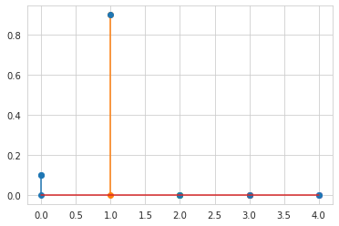

```python
plot_Bernoulli_pmf(0.9)
```

## Binomial distribution

We will plot $probability$ $mass$ $function$ (PMF) $B(p,n)$ - Binomial RV with parameters $p$ and $n$ (this RV represents the number of successes in $n$ independent Bernoulli experiments where each individual success probability is $p$).

```python
def plot_pmf(n, p):
    k = np.arange(0, n+1)
    P_binom = stats.binom.pmf(k, n, p)
    plt.stem(k, P_binom)
```

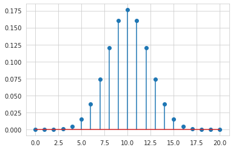

```python
plot_pmf(20, 0.5)
```

## Poisson distribution

This distribution expresses the probability of a given number of events occurring in a fixed interval of time or space if these events occur with a known constant rate and *independently* of the time since the last event.

For example, the amount of mails one receives each day (if receiving any particular piece of mail does not affect the arrival times of future pieces of mail), number of phone calls received by a call center per hour, the number of decay events per second from a radioactive source, etc.

This distribution allows arbitrary large number of events with non-zero probabilities!

```python
def possion(n, lamda):
    k = np.arange(0, n+1)
    possion_dis = stats.poisson.pmf(k, lamda)
    plt.plot(k, possion_dis)
```

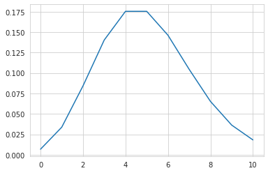

```python
possion(10, 5)
```

## Geometric distribution

The geometric distribution gives the probability that the first occurrence of success requires $k$ independent trials, each with success probability $p$.

```python
def geometric_dis(p, N):

    x= np.arange(1, N+1)

    y=stats.geom.pmf(x, p)
    z=stats.geom.cdf(x, p)

    plt.plot(x, y, 'o-', label='PDF')
    plt.plot(x, z, 'ro-', label='CDF')
    plt.legend()
```

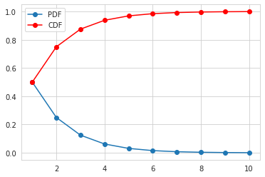

```python
geometric_dis(0.5, 10)
```

# Continuous Probability Distributions

### Probability Density Function (PDF)

```python
def normal(m, var):
    x = np.linspace(-10, 10, 1000)
    sig = var ** 0.5

    P_norm = stats.norm.pdf(x, m, sig)
    plt.plot(x, P_norm, 'r')

    cdf_norm = stats.norm.cdf(x, m, sig)
    plt.plot(x, cdf_norm, 'b')
```

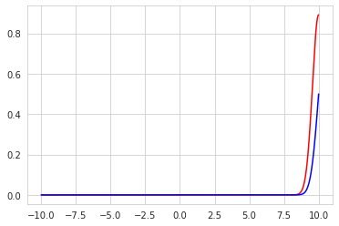

```python
normal(10, 0.2)
```

# Approximation of empirical PDF (normalized histogram) with continuous distributions

If we want to mathematicaly approximate distribution of some data, in general we need to specify the values at infinite number of points. This is not practical; hence approximation is performed from a certain family of distributions. Very often this family is taken to be a mixture of Gaussian distributions.

We will use data about temperature in city Detroit, and try to model the distirbution of temepratures using Gaussian mixture model.

```python
import pandas as pd

plt.style.use('seaborn-talk')
atributi = ['Detroit']
df = pd.read_csv("data/temperature.csv",usecols=atributi)
df.head()
```

|  | Detroit |
| --- | --- |
| 0 | NaN |
| 1 | 284.030000 |
| 2 | 284.069789 |
| 3 | 284.173965 |
| 4 | 284.278140 |

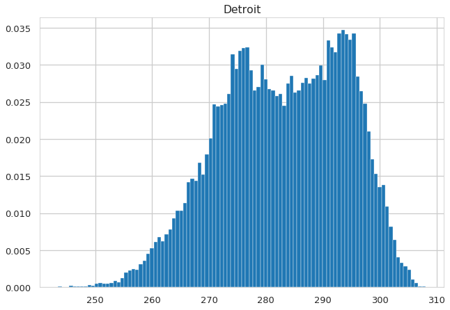

```python
hist = df.hist(normed=True,bins=100) # probability density function
plt.show()
```

#### Visual approximation:

We will try to approximate the histogram curve using:

1. Gaussian distribution: Norm(m=283K, sigma=11K),
2. Gaussian mixture: $0.5\cdot$ Norm(m=276K, sigma=6K)+$0.5\cdot$Norm(m=293K, sigma=6.5K),
3. Gaussian mixture: $0.5\cdot$ Norm(m=276K, sigma=6.5K)+$0.5\cdot$Norm(m=293K, sigma=6K)

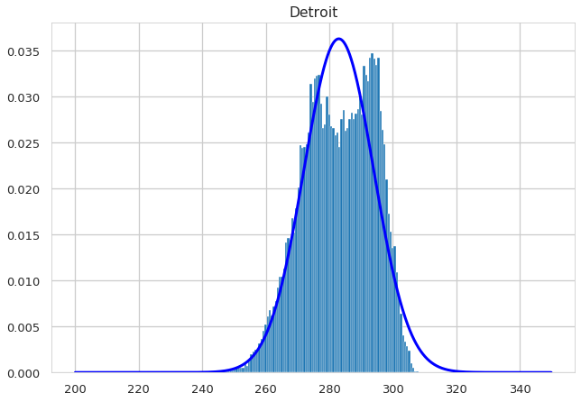

```python
from scipy.stats import norm

hist = df.hist(normed=True,bins=100) # pick the amount of bins based on data. General rule

step=0.1
x = np.arange(200, 350, step) #range
m=283 #mean (left <-- x --> right)
sig=11 #std (up <-- x --> down)
P_norm = norm.pdf(x, m, sig)

plt.plot(x, P_norm, 'b', linewidth=3.0)
plt.show()
```

### Guassian Mixture. It's distribution is the summation of 2 peaks.

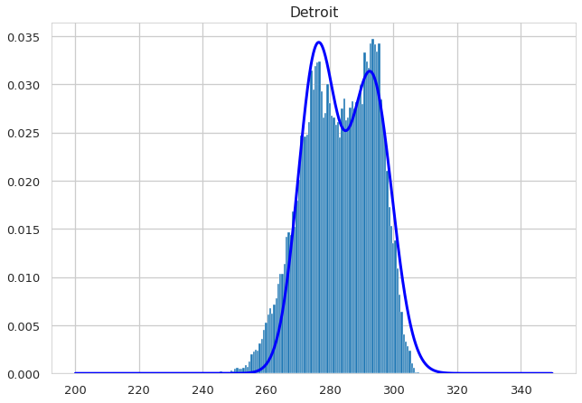

```python
hist = df.hist(normed=True,bins=100)
x = np.arange(200, 350, step)
m1=276
sig1=6
m2=293
sig2=6.5

P_norm_mix1 = 0.5*norm.pdf(x, m1, sig1)+0.5*norm.pdf(x, m2, sig2)

plt.plot(x, P_norm_mix1, 'b', linewidth=3.0)
plt.show()
```

Using the approximation we can for example find probability that temperature is between 275 and 290:

1. Gaussian mixture: $0.5\cdot$ Norm(m=276K, sigma=6.5K)+$0.5\cdot$Norm(m=293K, sigma=6K)

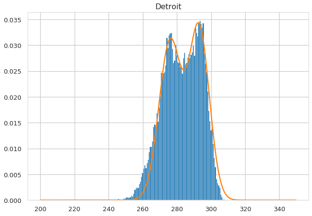

```python
hist = df.hist(normed=True, bins=100)

x = np.arange(200, 350, 0.2)

P_norm_mix2 = 0.5 *stats.norm.pdf(x, 276, 6.5) + 0.5*stats.norm.pdf(x, 293, 6)
plt.plot(x, P_norm_mix2)
```

# Integrating by hand:

```python
PP=np.array([step*z for x,z in zip(x,P_norm_mix2) if (x>275 and x<290)])
P_trazeno=PP.sum(axis=0)
print(P_trazeno)
```

```
0.21325789742690332
```